```r
library(dplyr)
```

```r
library(ggplot2)

flights <- tbl_df(read.csv("../general_data/flights.csv", stringsAsFactors = FALSE))
head(flights)
```

```
## # A tibble: 6 × 14
##                  date  hour minute   dep   arr dep_delay arr_delay carrier
##                 <chr> <int>  <int> <int> <int>     <int>     <int>   <chr>
## 1 2011-01-01 12:00:00    14      0  1400  1500         0       -10      AA
## 2 2011-01-02 12:00:00    14      1  1401  1501         1        -9      AA
## 3 2011-01-03 12:00:00    13     52  1352  1502        -8        -8      AA
## 4 2011-01-04 12:00:00    14      3  1403  1513         3         3      AA
## 5 2011-01-05 12:00:00    14      5  1405  1507         5        -3      AA
## 6 2011-01-06 12:00:00    13     59  1359  1503        -1        -7      AA
## # ... with 6 more variables: flight <int>, dest <chr>, plane <chr>,
## #   cancelled <int>, time <int>, dist <int>
```

```r
flights$date <- as.Date(flights$date)
head(flights)
```

```
## # A tibble: 6 × 14
##         date  hour minute   dep   arr dep_delay arr_delay carrier flight
##       <date> <int>  <int> <int> <int>     <int>     <int>   <chr>  <int>
## 1 2011-01-01    14      0  1400  1500         0       -10      AA    428
## 2 2011-01-02    14      1  1401  1501         1        -9      AA    428
## 3 2011-01-03    13     52  1352  1502        -8        -8      AA    428
## 4 2011-01-04    14      3  1403  1513         3         3      AA    428
## 5 2011-01-05    14      5  1405  1507         5        -3      AA    428
## 6 2011-01-06    13     59  1359  1503        -1        -7      AA    428
## # ... with 5 more variables: dest <chr>, plane <chr>, cancelled <int>,
## #   time <int>, dist <int>
```

```r
weather <- tbl_df(read.csv("../general_data/weather.csv", stringsAsFactors = FALSE))
head(weather)
```

```
## # A tibble: 6 × 14
##         date  hour  temp dew_point humidity pressure visibility wind_dir
##        <chr> <int> <dbl>     <dbl>    <int>    <dbl>      <dbl>    <chr>
## 1 2011-01-01     0  59.0      28.9       32    29.86         10      NNE
## 2 2011-01-01     1  57.2      28.4       33    29.88         10      NNE
## 3 2011-01-01     2  55.4      28.4       36    29.93         10      NNW
## 4 2011-01-01     3  53.6      28.4       38    29.94         10    North
## 5 2011-01-01     4    NA        NA       NA    29.99         10      NNW
## 6 2011-01-01     5    NA        NA       NA    30.02         10    North
## # ... with 6 more variables: wind_dir2 <int>, wind_speed <dbl>,
## #   gust_speed <dbl>, precip <dbl>, conditions <chr>, events <chr>
```

```r
weather$date <- as.Date(weather$date)
head(weather)
```

```
## # A tibble: 6 × 14
##         date  hour  temp dew_point humidity pressure visibility wind_dir
##       <date> <int> <dbl>     <dbl>    <int>    <dbl>      <dbl>    <chr>
## 1 2011-01-01     0  59.0      28.9       32    29.86         10      NNE
## 2 2011-01-01     1  57.2      28.4       33    29.88         10      NNE
## 3 2011-01-01     2  55.4      28.4       36    29.93         10      NNW
## 4 2011-01-01     3  53.6      28.4       38    29.94         10    North
## 5 2011-01-01     4    NA        NA       NA    29.99         10      NNW
## 6 2011-01-01     5    NA        NA       NA    30.02         10    North
## # ... with 6 more variables: wind_dir2 <int>, wind_speed <dbl>,
## #   gust_speed <dbl>, precip <dbl>, conditions <chr>, events <chr>
```

```r
planes <- tbl_df(read.csv("../general_data/planes.csv", stringsAsFactors = FALSE))
airports <- tbl_df(read.csv("../general_data/airports.csv", stringsAsFactors = FALSE))
head(planes)
```

```
## # A tibble: 6 × 9
##    plane  year               mfr          model no.eng no.seats speed
##    <chr> <int>             <chr>          <chr>  <int>    <int> <int>
## 1 N576AA  1991 MCDONNELL DOUGLAS DC-9-82(MD-82)      2      172    NA
## 2 N557AA  1993        MARZ BARRY      KITFOX IV      1        2    NA
## 3 N403AA  1974             RAVEN           S55A     NA        1    60
## 4 N492AA  1989 MCDONNELL DOUGLAS DC-9-82(MD-82)      2      172    NA
## 5 N262AA  1985 MCDONNELL DOUGLAS DC-9-82(MD-82)      2      172    NA
## 6 N493AA  1989 MCDONNELL DOUGLAS DC-9-82(MD-82)      2      172    NA
## # ... with 2 more variables: engine <chr>, type <chr>
```

```r
head(airports)
```

```
## # A tibble: 6 × 7
##    iata              airport             city state country      lat
##   <chr>                <chr>            <chr> <chr>   <chr>    <dbl>
## 1   00M             Thigpen       Bay Springs    MS     USA 31.95376
## 2   00R Livingston Municipal       Livingston    TX     USA 30.68586
## 3   00V          Meadow Lake Colorado Springs    CO     USA 38.94575
## 4   01G         Perry-Warsaw            Perry    NY     USA 42.74135
## 5   01J     Hilliard Airpark         Hilliard    FL     USA 30.68801
## 6   01M    Tishomingo County          Belmont    MS     USA 34.49167
## # ... with 1 more variables: long <dbl>
```

Loaded in four tables:

- flights: every flight departing Houston in 2011. [227,496, 14]
- weather: hourly weather data. [8723, 14]
- planes: plane metadata. [2853, 9]
- airports: airport metadata. [3376, 7]

### Fliter

**TO DO:** Find all flights: 1. TO SFO or OAK

```r
head(filter(flights, dest%in%c('SFO', 'OAK')))
```

```
## # A tibble: 6 × 14
##         date  hour minute   dep   arr dep_delay arr_delay carrier flight
##       <date> <int>  <int> <int> <int>     <int>     <int>   <chr>  <int>
## 1 2011-01-31     8     51   851  1052         1       -27      CO    170
## 2 2011-01-31    11     29  1129  1351         4         1      CO    270
## 3 2011-01-31    14     32  1432  1656         7         5      CO    370
## 4 2011-01-31    17     48  1748  2001         3        -4      CO    570
## 5 2011-01-31    21     43  2143  2338        50        24      CO    770
## 6 2011-01-31     7     29   729  1002        -1         2      CO    771
## # ... with 5 more variables: dest <chr>, plane <chr>, cancelled <int>,
## #   time <int>, dist <int>
```

2. in October

```r
library(lubridate)
head(filter(flights, month(as.POSIXct(date))==10))
```

```
## # A tibble: 6 × 14
##         date  hour minute   dep   arr dep_delay arr_delay carrier flight
##       <date> <int>  <int> <int> <int>     <int>     <int>   <chr>  <int>
## 1 2011-10-02    15     51  1551  1702         1        -3      AA    458
## 2 2011-10-03    15     51  1551  1655         1       -10      AA    458
## 3 2011-10-04    15     48  1548  1656        -2        -9      AA    458
## 4 2011-10-05    15     52  1552  1700         2        -5      AA    458
## 5 2011-10-06    15     50  1550  1704         0        -1      AA    458
## 6 2011-10-07    15     52  1552  1700         2        -5      AA    458
## # ... with 5 more variables: dest <chr>, plane <chr>, cancelled <int>,
## #   time <int>, dist <int>
```

3. delayed by more than an hour

```r
head(filter(flights, dep_delay > 60 ))
```

```
## # A tibble: 6 × 14
##         date  hour minute   dep   arr dep_delay arr_delay carrier flight
##       <date> <int>  <int> <int> <int>     <int>     <int>   <chr>  <int>
## 1 2011-01-17    15     30  1530  1634        90        84      AA    428
## 2 2011-01-20    15      7  1507  1622        67        72      AA    428
## 3 2011-01-14    21     19  2119  2229        74        69      AA    533
## 4 2011-01-09    18     35  1835  1951       125       126      AA   1121
## 5 2011-01-11    17     52  1752  1855        82        70      AA   1121
## 6 2011-01-10    19     34  1934  2235        99        80      AA   1294
## # ... with 5 more variables: dest <chr>, plane <chr>, cancelled <int>,
## #   time <int>, dist <int>
```

4. departed between midnight and five am

```r
head(filter(flights, hour>=0, hour<=5))
```

```
## # A tibble: 6 × 14
##         date  hour minute   dep   arr dep_delay arr_delay carrier flight
##       <date> <int>  <int> <int> <int>     <int>     <int>   <chr>  <int>
## 1 2011-01-01     5     57   557   906        -3        -9      AA   1994
## 2 2011-01-02     5     54   554   912        -6        -3      AA   1994
## 3 2011-01-03     5     55   555   905        -5       -10      AA   1994
## 4 2011-01-04     5     58   558   923        -2         8      AA   1994
## 5 2011-01-05     5     55   555   914        -5        -1      AA   1994
## 6 2011-01-07     5     56   556   905        -4       -10      AA   1994
## # ... with 5 more variables: dest <chr>, plane <chr>, cancelled <int>,
## #   time <int>, dist <int>
```

5. where the arrival delay was more than twice the departure delay

```r
head(filter(flights, arr_delay > 2*dep_delay))
```

```
## # A tibble: 6 × 14
##         date  hour minute   dep   arr dep_delay arr_delay carrier flight
##       <date> <int>  <int> <int> <int>     <int>     <int>   <chr>  <int>
## 1 2011-01-03    13     52  1352  1502        -8        -8      AA    428
## 2 2011-01-07    13     59  1359  1509        -1        -1      AA    428
## 3 2011-01-16    13     59  1359  1509        -1        -1      AA    428
## 4 2011-01-19    13     56  1356  1503        -4        -7      AA    428
## 5 2011-01-24    13     56  1356  1513        -4         3      AA    428
## 6 2011-01-03     7     17   717   834        -3        -1      AA    460
## # ... with 5 more variables: dest <chr>, plane <chr>, cancelled <int>,
## #   time <int>, dist <int>
```

### select

different ways to select the two delay varibles

```r
select(flights, arr_delay, dep_delay)
```

```
## # A tibble: 227,496 × 2
##    arr_delay dep_delay
##        <int>     <int>
## 1        -10         0
## 2         -9         1
## 3         -8        -8
## 4          3         3
## 5         -3         5
## 6         -7        -1
## 7         -1        -1
## 8        -16        -5
## 9         44        43
## 10        43        43
## # ... with 227,486 more rows
```

```r
select(flights, arr_delay:dep_delay)
```

```
## # A tibble: 227,496 × 2
##    arr_delay dep_delay
##        <int>     <int>
## 1        -10         0
## 2         -9         1
## 3         -8        -8
## 4          3         3
## 5         -3         5
## 6         -7        -1
## 7         -1        -1
## 8        -16        -5
## 9         44        43
## 10        43        43
## # ... with 227,486 more rows
```

```r
select(flights, ends_with("delay"))
```

```
## # A tibble: 227,496 × 2
##    dep_delay arr_delay
##        <int>     <int>
## 1          0       -10
## 2          1        -9
## 3         -8        -8
## 4          3         3
## 5          5        -3
## 6         -1        -7
## 7         -1        -1
## 8         -5       -16
## 9         43        44
## 10        43        43
## # ... with 227,486 more rows
```

```r
select(flights, contains("delay"))
```

```
## # A tibble: 227,496 × 2
##    dep_delay arr_delay
##        <int>     <int>
## 1          0       -10
## 2          1        -9
## 3         -8        -8
## 4          3         3
## 5          5        -3
## 6         -1        -7
## 7         -1        -1
## 8         -5       -16
## 9         43        44
## 10        43        43
## # ... with 227,486 more rows
```

### arrange

**TO DO:** Order the flights by departure date and time.

```r
head(arrange(flights, date, hour, minute))
```

```
## # A tibble: 6 × 14
##         date  hour minute   dep   arr dep_delay arr_delay carrier flight
##       <date> <int>  <int> <int> <int>     <int>     <int>   <chr>  <int>
## 1 2011-01-01     0      1     1   621         2        24      CO   1542
## 2 2011-01-01     5     49   549   846        -1       -11      DL   1248
## 3 2011-01-01     5     57   557   906        -3        -9      AA   1994
## 4 2011-01-01     5     58   558  1006        -2        -6      CO     89
## 5 2011-01-01     5     59   559   758        -1         6      US    270
## 6 2011-01-01     6      0   600   657         0       -13      MQ   3265
## # ... with 5 more variables: dest <chr>, plane <chr>, cancelled <int>,
## #   time <int>, dist <int>
```

Which flights were most delayed?

```r
head(arrange(flights, desc(dep_delay)), n=1)
```

```
## # A tibble: 1 × 14
##         date  hour minute   dep   arr dep_delay arr_delay carrier flight
##       <date> <int>  <int> <int> <int>     <int>     <int>   <chr>  <int>
## 1 2011-08-01     1     56   156   452       981       957      CO      1
## # ... with 5 more variables: dest <chr>, plane <chr>, cancelled <int>,
## #   time <int>, dist <int>
```

Which flights caught up the most time during the flight?

```r
head(arrange(flights, desc(dep_delay-arr_delay)))
```

```
## # A tibble: 6 × 14
##         date  hour minute   dep   arr dep_delay arr_delay carrier flight
##       <date> <int>  <int> <int> <int>     <int>     <int>   <chr>  <int>
## 1 2011-07-03    19     14  1914  2039        -1       -70      XE   2804
## 2 2011-12-24    12      9  1209  1346        54        -3      CO   1669
## 3 2011-12-24    21     29  2129  2337        -1       -55      CO   1552
## 4 2011-12-24    21     17  2117  2258         2       -51      CO   1712
## 5 2011-12-25     7     41   741   926        -4       -57      OO   4591
## 6 2011-08-26    21      7  2107  2205        -3       -55      OO   2003
## # ... with 5 more variables: dest <chr>, plane <chr>, cancelled <int>,
## #   time <int>, dist <int>
```

### mutate

**TO DO:** Compute speed in mph from time (in minutes) and distance (in miles). Which flight flew the fastest?

```r
head(
flights %>%
  mutate(speed = dist/(time/60)) %>%
  arrange(desc(speed))
)
```

```
## # A tibble: 6 × 15
##         date  hour minute   dep   arr dep_delay arr_delay carrier flight
##       <date> <int>  <int> <int> <int>     <int>     <int>   <chr>  <int>
## 1 2011-08-31    12     55  1255  1346         0        -7      CO   1646
## 2 2011-01-08    16     20  1620  1730         0       -27      EV   5229
## 3 2011-02-21     8     34   834  1156       -11       -10      US    944
## 4 2011-10-09    11      4  1104  1117        -1       -13      XE   4634
## 5 2011-03-09    19      5  1905  2225         0       -10      CO    500
## 6 2011-02-05    10     52  1052  1434         7       -33      CO    106
## # ... with 6 more variables: dest <chr>, plane <chr>, cancelled <int>,
## #   time <int>, dist <int>, speed <dbl>
```

Add a new variable that shows how much time was made up or lost in flight.

```r
head(mutate(flights, madeup = dep_delay - arr_delay))
```

```
## # A tibble: 6 × 15
##         date  hour minute   dep   arr dep_delay arr_delay carrier flight
##       <date> <int>  <int> <int> <int>     <int>     <int>   <chr>  <int>
## 1 2011-01-01    14      0  1400  1500         0       -10      AA    428
## 2 2011-01-02    14      1  1401  1501         1        -9      AA    428
## 3 2011-01-03    13     52  1352  1502        -8        -8      AA    428
## 4 2011-01-04    14      3  1403  1513         3         3      AA    428
## 5 2011-01-05    14      5  1405  1507         5        -3      AA    428
## 6 2011-01-06    13     59  1359  1503        -1        -7      AA    428
## # ... with 6 more variables: dest <chr>, plane <chr>, cancelled <int>,
## #   time <int>, dist <int>, madeup <int>
```

How did I compute hour and minute from dep?

```r
head(mutate(flights, my_hour = dep%/%100, my_min = dep%%100))
```

```
## # A tibble: 6 × 16
##         date  hour minute   dep   arr dep_delay arr_delay carrier flight
##       <date> <int>  <int> <int> <int>     <int>     <int>   <chr>  <int>
## 1 2011-01-01    14      0  1400  1500         0       -10      AA    428
## 2 2011-01-02    14      1  1401  1501         1        -9      AA    428
## 3 2011-01-03    13     52  1352  1502        -8        -8      AA    428
## 4 2011-01-04    14      3  1403  1513         3         3      AA    428
## 5 2011-01-05    14      5  1405  1507         5        -3      AA    428
## 6 2011-01-06    13     59  1359  1503        -1        -7      AA    428
## # ... with 7 more variables: dest <chr>, plane <chr>, cancelled <int>,
## #   time <int>, dist <int>, my_hour <dbl>, my_min <dbl>
```

### Grouped summarise

How might you summarise dep_delay for each day?

```r
by_date <- group_by(flights, date)
delays <- summarise(by_date,
  mean = mean(dep_delay, na.rm = TRUE),
  median = median(dep_delay, na.rm = TRUE),
  q75 = quantile(dep_delay, 0.75, na.rm = TRUE),
  over_15 = mean(dep_delay > 15, na.rm = TRUE),
  over_30 = mean(dep_delay > 30, na.rm = TRUE),
  over_60 = mean(dep_delay > 60, na.rm = TRUE)
)
head(delays)
```

```
## # A tibble: 6 × 7
##         date      mean median   q75   over_15    over_30    over_60
##       <date>     <dbl>  <dbl> <dbl>     <dbl>      <dbl>      <dbl>
## 1 2011-01-01 10.708029      3  15.0 0.2445255 0.12043796 0.03284672
## 2 2011-01-02 15.661169      7  20.0 0.3178411 0.15892054 0.05697151
## 3 2011-01-03 13.414286      4  18.0 0.2714286 0.14285714 0.05285714
## 4 2011-01-04 11.903614      5  18.0 0.2891566 0.12736661 0.02581756
## 5 2011-01-05  6.325383      1   8.5 0.1533220 0.05281090 0.01192504
## 6 2011-01-06  5.283333      0   7.0 0.1257576 0.05757576 0.02424242
```

### Data Pipelines

```r
hourly_delay <- flights %>%
  filter(!is.na(dep_delay)) %>%
  group_by(date, hour) %>%
  summarise(delay = mean(dep_delay), n = n()) %>%
  filter(n > 10)
```

** TO DO:** Which destinations have the highest average delays?

```r
flights %>%
  filter(!is.na(arr_delay)) %>%
  group_by(dest) %>%
  summarise(
    arr_delay = mean(arr_delay),
    n = n()
  ) %>%
  arrange(desc(arr_delay))
```

```
## # A tibble: 116 × 3
##     dest arr_delay     n
##    <chr>     <dbl> <int>
## 1    ANC  26.08065   124
## 2    CID  17.80049   406
## 3    DSM  15.95110   634
## 4    SFO  14.89036  2800
## 5    BPT  14.33333     3
## 6    GRR  13.71729   665
## 7    DAY  13.67117   444
## 8    VPS  12.45718   864
## 9    ECP  12.42222   720
## 10   SAV  12.33137   851
## # ... with 106 more rows
```

```r
#.Last.value %>% View()  # Nifty trick to see more data
```

Which flights (i.e. carrier + flight) happen every day? Where do they fly to?

```r
flights %>%
  group_by(carrier, flight, dest) %>%
  tally(sort = TRUE) %>%
  filter(n==365)
```

```
## Source: local data frame [7 x 4]
## Groups: carrier, flight [7]
##
##   carrier flight  dest     n
##     <chr>  <int> <chr> <int>
## 1      AA   1294   MIA   365
## 2      AS    731   SEA   365
## 3      CO      1   HNL   365
## 4      CO     62   EWR   365
## 5      CO     89   EWR   365
## 6      CO    106   EWR   365
## 7      MQ   3859   ORD   365
```

```r
#.Last.value %>% View()
```

On average, how do delays (of non-cancelled flights) vary over the course of a day?

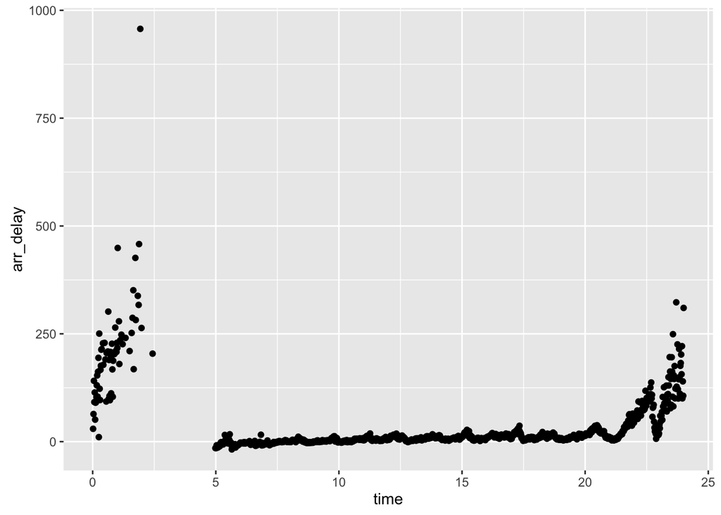

```r
per_hour <- flights %>%
  filter(cancelled == 0) %>%
  mutate(time = hour + minute / 60) %>%
  group_by(time) %>%
  summarise(
    arr_delay = mean(arr_delay, na.rm = TRUE),
n = n() )

qplot(time, arr_delay, data = per_hour)
```

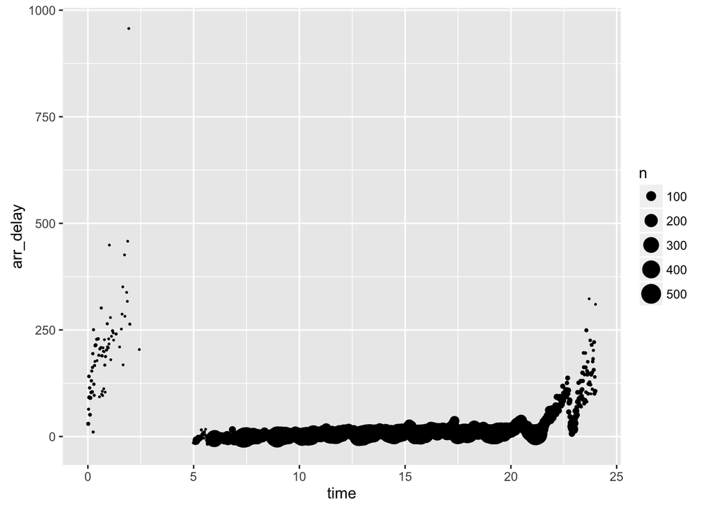

```r
qplot(time, arr_delay, data = per_hour, size = n) + scale_size_area()
```

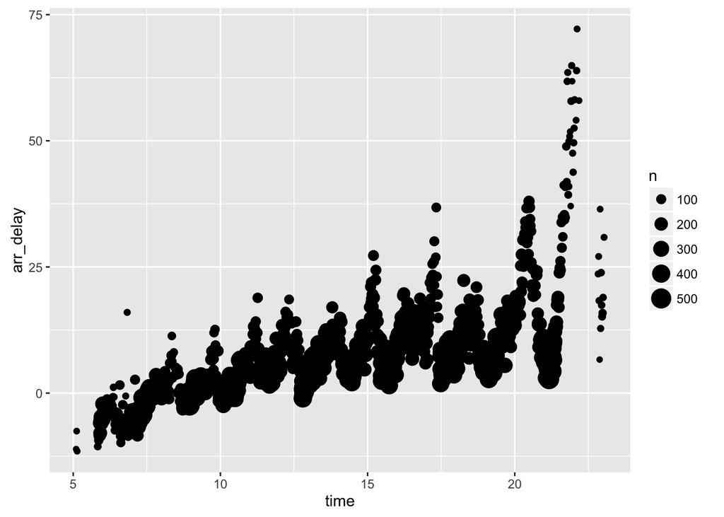

```r
qplot(time, arr_delay, data = filter(per_hour, n > 30), size = n) +
scale_size_area()
```

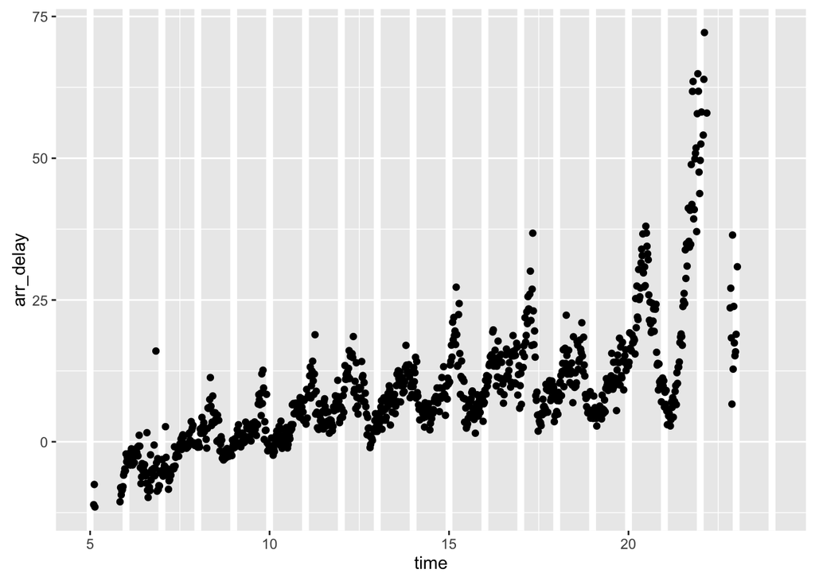

```r
ggplot(filter(per_hour, n > 30), aes(time, arr_delay)) +
  geom_vline(xintercept = 5:24, colour = "white", size = 2) +
  geom_point()
```